# Chronic Disease Indicators - Analysis

Maggie Kohn

12/08/2025

This analysis examines how socioeconomic conditions relate to the burden of chronic disease across the United States. The Centers for Disease Control and Prevention’s [Chronic Disease Indicators (CDI)](https://data.cdc.gov/Chronic-Disease-Indicators/U-S-Chronic-Disease-Indicators/hksd-2xuw/about_data) dataset aggregates and standardizes public health indicators across all U.S. states and territories.

## Raw CDI Dataset

The original CDI dataset contains 309,215 observations and 34 variables. The variable data types are as follows:

- **Numeric** Variables: 6
- **Character** Variables: 18
- **Logical** Variables: 10

Missing data occurs across several variables:

- All **logical** variables appear to be empty placeholders and will be excluded from this analysis.
- The **`DataValueFootnote`** variable documents reasons for missingness in `DataValue` and therefore contains many missing entries in rows where a value is present because it is only populated when data is suppressed or unavailable.
- Overall, there are 100,019 rows with missingness in the **`DataValue`** column with 90,271 of those occurring in observations stratified by race/ethnicity. Based on the `DataValueFootnote`, these values are suppressed because sample sizes were too small to report which makes direct comparison between these groups unreliable.

## Clean CDI Dataset

After removing empty variables and filtering for relevant observations, the cleaned dataset contains 106,338 observations and 22 variables. The variable data types are as follows:

- Numeric Variables: 4
- Character Variables: 18
- Logical Variables: 0

### Data Dictionary

|  | Variable Name | Variable Type | Description |
| --- | --- | --- | --- |
| 1 | DataSource | Character | Source for the reported value |
| 2 | DataValue | Numeric | Reported value |
| 3 | DataValueFootnote | Character | Reason of missingness, if applicable |
| 4 | DataValueFootnoteSymbol | Character | Symbol for footnote |
| 5 | DataValueType | Character | Method of measurement |
| 6 | DataValueTypeID | Character | Unique data value type identifier |
| 7 | DataValueUnit | Character | Unit of measurement |
| 8 | Geolocation | Character | Location coordinates (latitude, longitude) |
| 9 | HighConfidenceLimit | Numeric | Upper 95% confidence interval |
| 10 | LocationAbbr | Character | State or territory abbreviation |

[output cut: 12 more lines]

### Indicators of Health

#### Life Expectancy at Birth

Life expectancy at birth declined nationwide between 2019 and 2020 (Figure 1). Hawaii maintained the highest life expectancy, while Mississippi remained lowest.

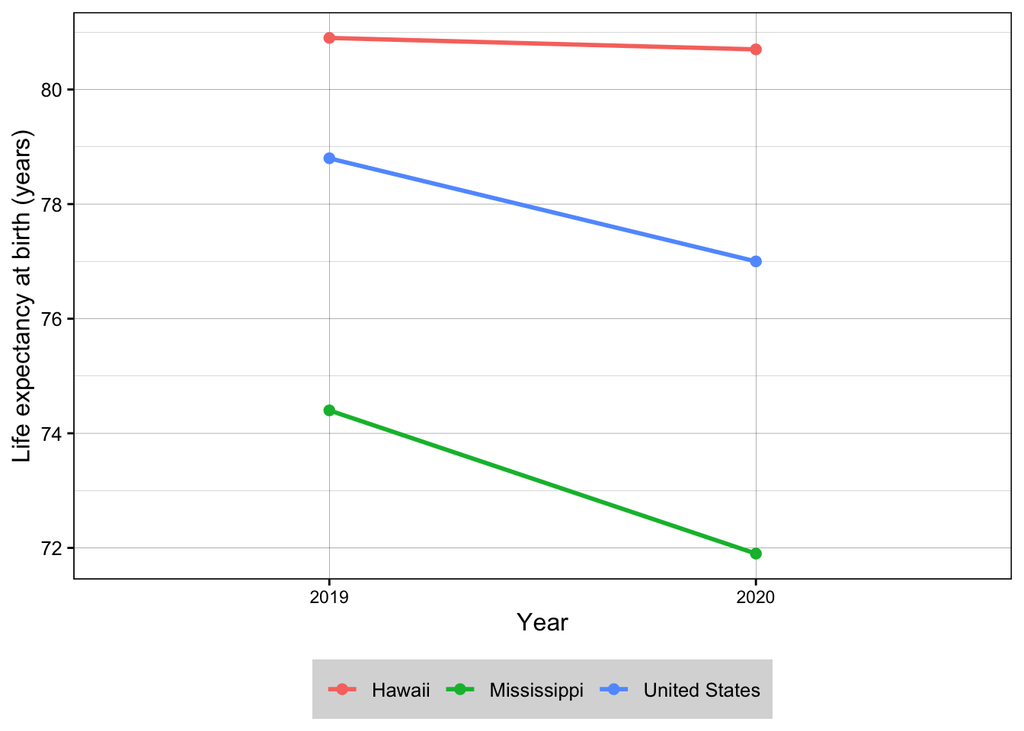

Figure 1. Life expectancy at birth declined in the United States from 2019 to 2020.

#### Social Determinants of Health

Key socioeconomic indicators showed mixed changes between 2019 and 2021 (Figure 2). Uninsured rate improved but lack of routine checkups increased, poverty levels remained stable, and unemployment rose. Poverty and unemployment data is missing for 2020 and 2022.

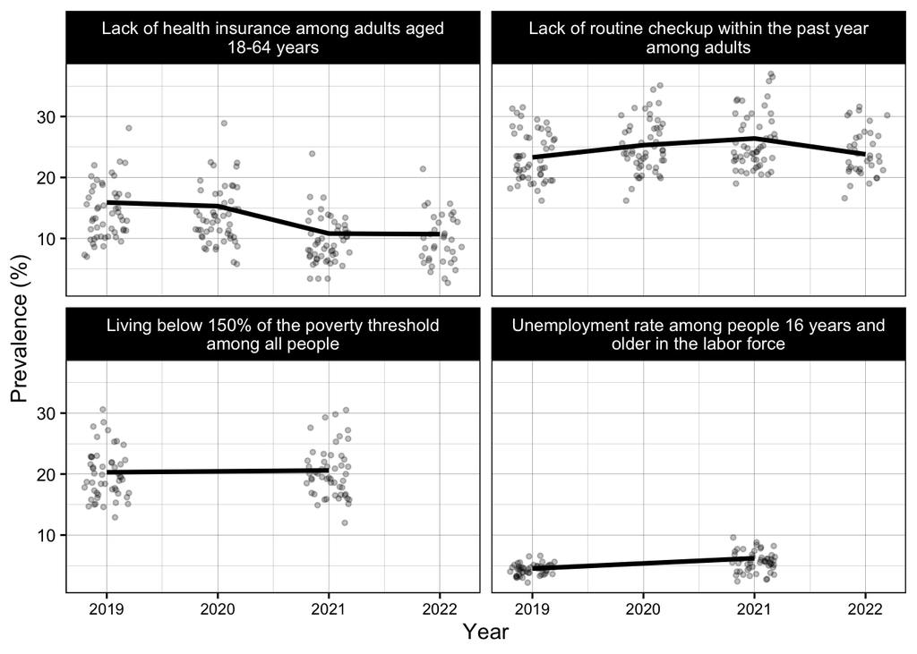

Figure 2. Social determinants of health indicators across U.S. states and territories. Points represent individual states (jittered for visibility). The solid line indicates the national average.

### Chronic Diseases

#### Mortality Rates

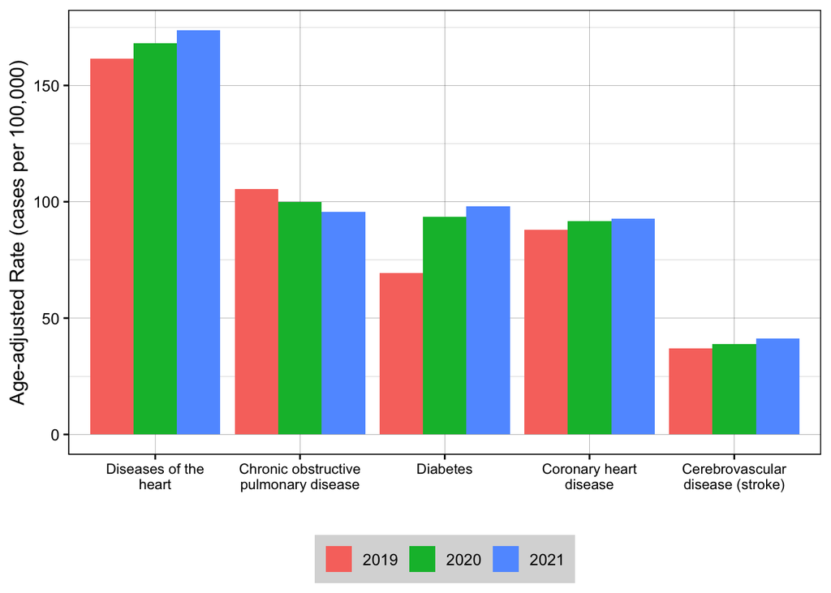

Figure 3. National age-adjusted mortality rates (per 100,000) for major chronic diseases between 2019 and 2021.

#### Hospitalization for COPD and Heart Failure

COPD hospitalizations decreased from 2019 to 2020 for both men and women, followed by a modest increase in 2021 (Figure 4). Heart failure hospitalizations followed the same pattern at a lower overall rate. Men consistently had higher rates than women across all years.

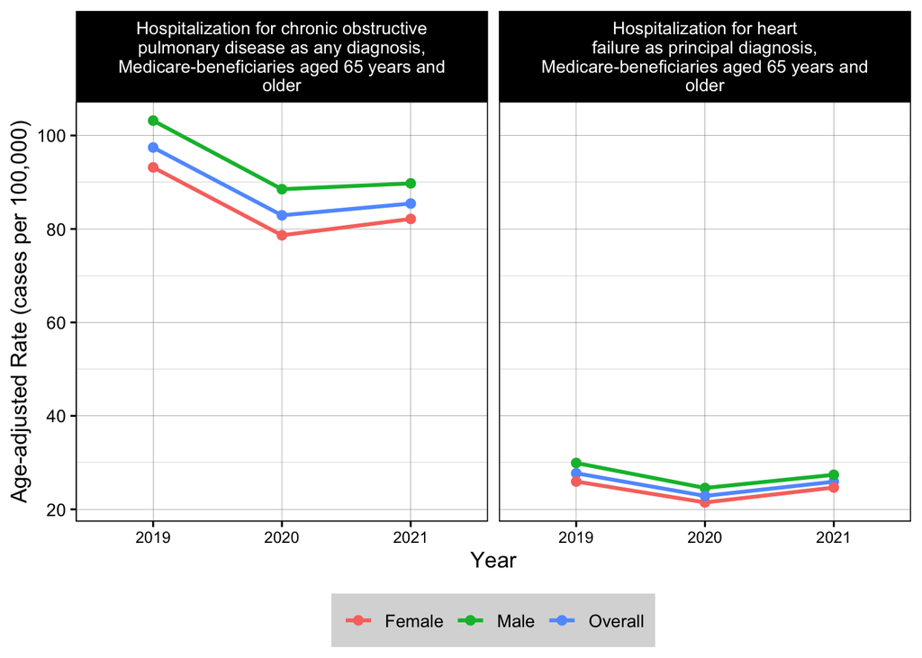

Figure 4. Age-adjusted hospitalization rates among Medicare beneficiaries aged 65 years and older for COPD and heart failure, stratified by sex.

### Indicators of Health and Chronic Diseases

#### Diabetes Prevalence vs Uninsured Prevalence

Across all four years, states with higher uninsured prevalence tend to have higher rates of diabetes (Figure 5). The positive association was consistent from 2019 through 2022.

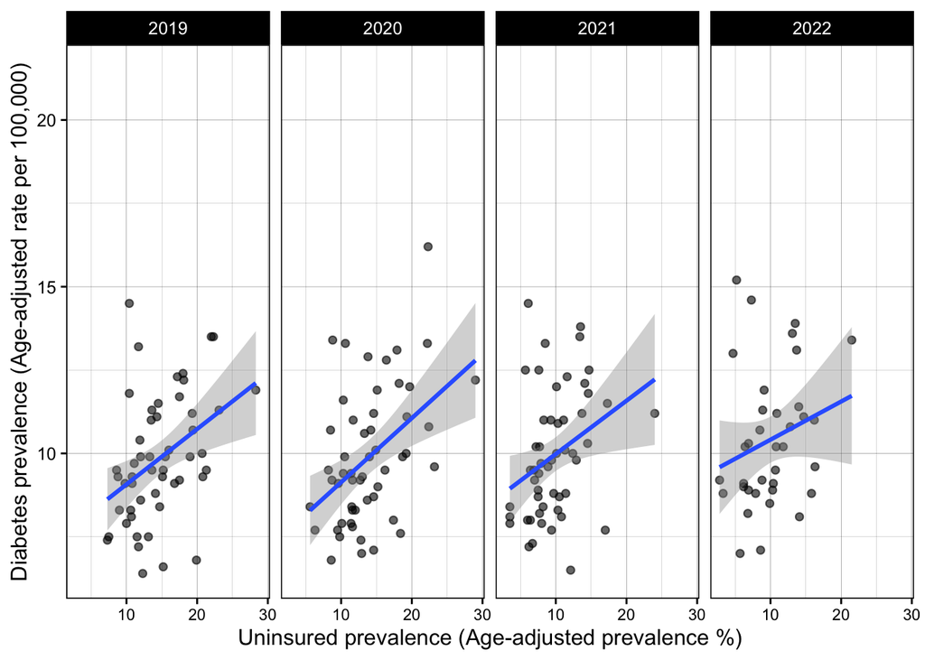

Figure 5. Association between state level diabetes prevalence and lack of health insurance between 2019 and 2022. Points represent states values. The blue line shows the fitted linear trend with 95% confidence intervals.

#### Mortality Rates vs Uninsured Prevalence

Across all three years, states with higher uninsured rates tended to have higher mortality rates (Figure 6). The positive association was modest in 2019 and 2020, and appeared stronger in 2021, when the slope of the relationship steepened.

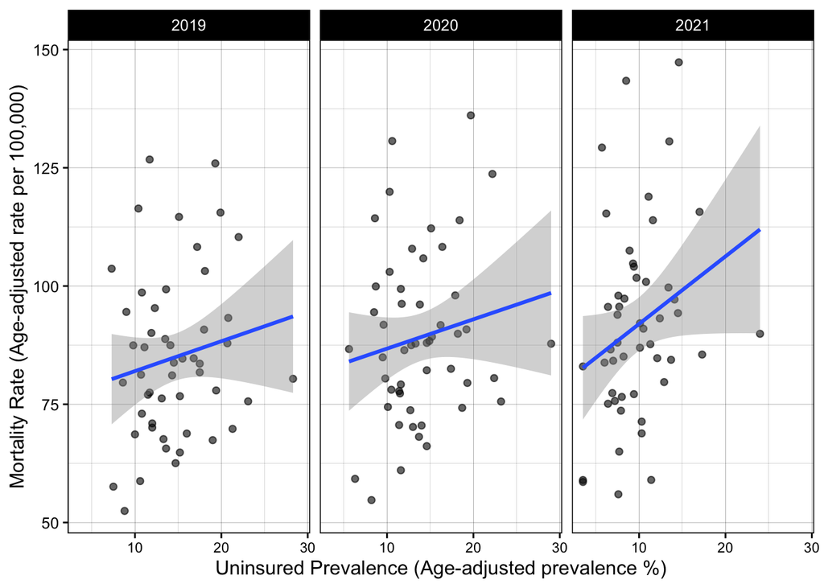

Figure 6. Association between mortality and lack of health insurance across U.S. states, 2019–2021. Points represent states values. The blue line shows the fitted linear trend with 95% confidence intervals.